# Анализ данных для авиакомпании

В исследовании для авиакомпании нам необходимо выявить популярные направления авиаперелетов в августе 2018 года. Также на основе данных за сентябрь 2018 года нам нужно установить, на каких самолетах совершается большее число рейсов.

## Открытие данных

Импортируем pandas и сохраним две таблицы:

- `airplane` — с данными о модели самолета и общем количестве рейсов в сентябре 2018 года;
- `cities` — с информацией о среднем числе рейсов, прибывающих ежедневно в августе 2018 года.

```python
import pandas as pd
import matplotlib.pyplot as plt
import plotly.express as px
```

```python
airplane = pd.read_csv('/datasets/query_1.csv')
cities = pd.read_csv('/datasets/query_3.csv')
```

```python
#выведем таблицы на экран
display(airplane)
display(cities.sample(10, random_state = 9))
```

|  | model | flights_amount |
| --- | --- | --- |
| 0 | Airbus A319-100 | 607 |
| 1 | Airbus A321-200 | 960 |
| 2 | Boeing 737-300 | 630 |
| 3 | Boeing 767-300 | 600 |
| 4 | Boeing 777-300 | 300 |
| 5 | Bombardier CRJ-200 | 4446 |
| 6 | Cessna 208 Caravan | 4557 |
| 7 | Sukhoi SuperJet-100 | 4185 |

|  | city | average_flights |
| --- | --- | --- |
| 75 | Ставрополь | 2.000000 |
| 42 | Мирный | 6.290323 |
| 46 | Нальчик | 3.000000 |
| 68 | Салехард | 2.000000 |
| 3 | Архангельск | 5.354839 |
| 39 | Магнитогорск | 4.000000 |
| 23 | Иркутск | 6.032258 |
| 20 | Екатеринбург | 11.322581 |
| 70 | Санкт-Петербург | 31.161290 |
| 73 | Советский | 9.000000 |

**Вывод**

В таблице `airplane` хранятся данные о двух моделях самолетов Airbus, трех моделях Boeing, а также по одной модели Bombardier, Cessna и Sukhoi SuperJet-100. Причем у последних трех моделей число полетов значительно больше, чем у Airbus и Boeing.  
Таблица `cities` содержит данные о среднем количестве полетов, совершаемых ежедневно в каждый из городов. Ожидаемо, аэропорты в туристических городах-миллионниках (Санкт-Петербург или Екатеринбург) принимают больше рейсов, чем в провинции, например в Салехарде или Нальчике.

## Предобработка данных

Изучим типы данных в таблицах:

```python
airplane.info()
```

```
<class 'pandas.core.frame.DataFrame'>
RangeIndex: 8 entries, 0 to 7
Data columns (total 2 columns):
model             8 non-null object
flights_amount    8 non-null int64
dtypes: int64(1), object(1)
memory usage: 256.0+ bytes
```

В `airplane` нет пропусков, типы данных заменять не нужно. В таблице всего 8 строк, и мы визуально можем определить, что дубликатов в ней тоже нет. А причины такой большой разницы в числовых значениях нам предстоит выявить далее.

Изучим данные в таблице `cities`:

```python
cities.info()
```

```
<class 'pandas.core.frame.DataFrame'>
RangeIndex: 101 entries, 0 to 100
Data columns (total 2 columns):
city               101 non-null object
average_flights    101 non-null float64
dtypes: float64(1), object(1)
memory usage: 1.7+ KB
```

В `cities` также нет пропусков. Можем для удобства заменить тип данных с `float64` на `float32` — это позволит нам сэкономить память:

```python
cities['average_flights'] = pd.to_numeric(cities['average_flights'], downcast='float')
cities.info()
```

```
<class 'pandas.core.frame.DataFrame'>
RangeIndex: 101 entries, 0 to 100
Data columns (total 2 columns):
city               101 non-null object
average_flights    101 non-null float32
dtypes: float32(1), object(1)
memory usage: 1.3+ KB
```

Видим, что тип данных сменился на `float32`.  
Рассмотрим стандартное отклонение, среднее и другие характерные значения:

```python
cities['average_flights'].describe()
```

```
count    101.000000
mean       5.494189
std       13.119791
min        1.000000
25%        2.000000
50%        3.000000
75%        5.870968
max      129.774200
Name: average_flights, dtype: float64
```

Среднее значение составляет приблизительно 5,5, стандартное отклонение — 13,1. Стандартное отклонение значительно превышает среднее, что говорит нам о возможном наличии выбросов или аномальных значений. Также наблюдаем, что значение 3-го квартиля (равен 6) сильно меньше максимального — 130. Вероятно, это максимальное значение и есть аномалия.

Проверим, есть ли в таблице дублирующиеся значения:

```python
cities.duplicated().sum()
```

```
0
```

Дубликатов в этой таблице также нет.

**Вывод**

В таблице `cities` для экономии памяти привели среднее количество полетов к формату `float32`. Также в этой таблице обнаружили слишком большое значение среднего числа рейсов — максимальное значение равно 130 при среднем, равном 5,5 рейсов, и стандартном отклонении, равном 13,1. Причины такого большого разброса изучим далее.

## Исследовательский анализ данных

Выясним самые популярные направления авиаперелетов в августе 2018 года. А также узнаем, на каких самолетах летали больше в сентябре 2018.

### Топ-10 городов по числу рейсов

Определим 10 самых популярных городов по среднему количеству полетов, совершаемых ежедневно.

```python
#сохраним в переменной top_10
top_10 = cities.sort_values(by='average_flights', ascending = False).head(10)
top_10
```

|  | city | average_flights |
| --- | --- | --- |
| 43 | Москва | 129.774200 |
| 70 | Санкт-Петербург | 31.161291 |
| 54 | Новосибирск | 17.322580 |
| 33 | Красноярск | 11.580646 |
| 20 | Екатеринбург | 11.322580 |
| 67 | Ростов-на-Дону | 10.193548 |
| 63 | Пермь | 10.129032 |
| 10 | Брянск | 10.000000 |
| 74 | Сочи | 9.612904 |
| 84 | Ульяновск | 9.580646 |

**Вывод**

В целом, полученные данные не противоречат действительности. На первом месте Москва с тремя международными аэропортами и почти  
130 ежедневно принимаемыми рейсами. На втором месте Санкт-Петербург, в который в среднем прилетает 31,1 самолет каждый день. Следом в топ-10 идут города-миллионеры: Новосибирск, Красноярск и Екатеринбург. Во второй половине таблицы города с прибл. 10 ежедневно совершаемыми рейсами: Ростов-на-Дону, Сочи, Ульяновск, Пермь и Брянск.

### Число рейсов для каждой модели самолета

Построим график, чтобы посмотреть, сколько рейсов совершил каждый самолет в течение сентября 2018 года:

```python
#создадим функцию для построения графиков:
#сортирует таблицу по значениям в y-колонке в порядке убывания и строит столбчатый график
def bar_graph_px(data, x_column, y_column, title, x_label, y_label):
    df = data.sort_values(by=y_column, ascending=False)
    fig = px.bar(df, x=x_column, y=y_column, title=title, labels={x_column:x_label, y_column:y_label})
    fig.show()

#построим график для числа рейсов каждой модели самолетов
bar_graph_px(airplane, 'model', 'flights_amount', 'Количество рейсов для каждой модели самолета, сентябрь 2018 г.',
          'Модели самолетов', 'Число рейсов')
```

[interactive chart not shown]

По числу рейсов на первом месте Сessna 208 Caravan — американский легкий одномоторный турбовинтовой самолет, вместимостью до  
13 пассажиров. На втором месте канадский региональный самолет Bombardier CRJ-200 на 50 пассажиров. На счету этих двух моделей приблизительно по 4,5 тысячи рейсов в месяц. Максимальная дальность полета составляет от 1500 до 3000 км, поэтому их чаще всего используют для небольших перелетов в пределах одного региона — у таких самолетов меньше расход топлива и траты на эксплуатацию.

Чуть более 4 тысяч перелетов в месяц совершает Sukhoi Superjet 100 («Сухой Суперджет 100») — ближнемагистральный самолет, рассчитанный на дальность полета в 3050 км. Эта модель самолета российского производства, поэтому в России он эксплуатируется больше всего. Здесь также играет роль его вместимость — не более 108 пассажиров, — он выгоднее для авиаперевозок внутри одного или нескольких регионов, чем, к примеру, аэробусы.

В четыре раза меньше рейсов у трех среднемагистральных самолетов конкурирующих между собой компаний Boeing и Airbus. Это французские лайнеры Airbus A321-200 (вместимостью до 220 человек) и Airbus A319-100 (до 158 пассажиров) и американский Boeing 737-300  
(до 149 пассажиров). Такие самолеты также часто используются для региональных перелетов, но их максимальная дальность гораздо больше, чем у ближнемагистральных. Это позволяет авиакомпаниям широко использовать эти самолеты для перелетов и внутри страны, и в ближние страны.

Последними в списке по числу рейсов идут два аэробуса от Boeing: Boeing 767-300 и Boeing 777-300. Эти самолеты обладают самой большой вместительностью (325 и 550 пассажиров, соответственно) и дальностью полетов (более 6000 км). Авиакомпаниям экономически невыгодно использовать аэробусы полупустыми, поэтому чаще всего такие самолеты летают на популярных, загруженных направлениях, а также на дальних и межконтинентальных перевозках.

**Вывод**

### Среднее количество рейсов в каждом городе

Построим график для среднего числа рейсов в каждый город в день в августе 2018 года:

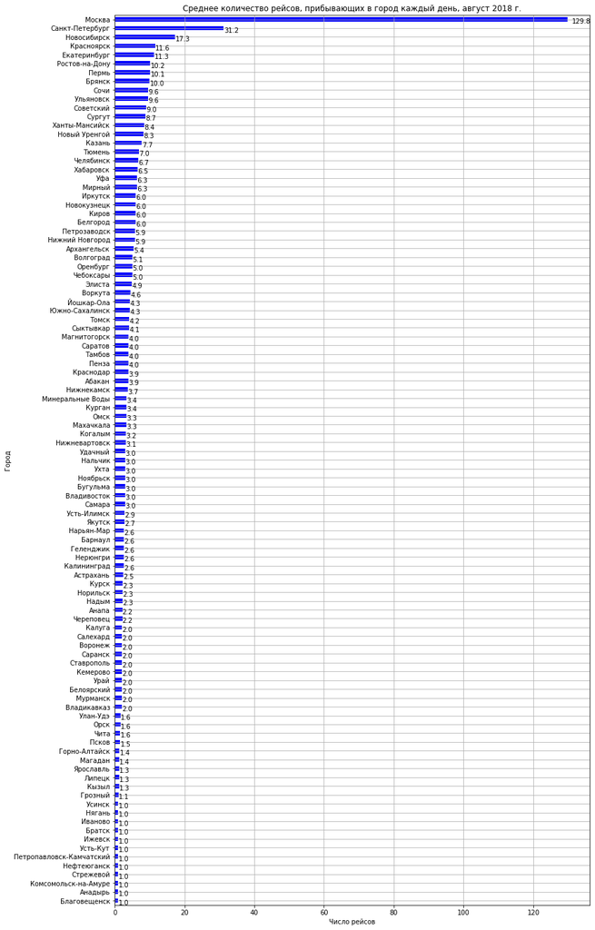

```python
#строим горизонтальный столбчатый график
plot = (cities
        .sort_values(by='average_flights')
        .plot.barh(x='city', y='average_flights', figsize=(13, 25), legend=False, grid=True, color='blue')
       )

for rect in plot.patches:
    width = rect.get_width()
    plot.text(width*1.01, rect.get_y(), round(width, 1), ha='left', va='center')

plt.title('Среднее количество рейсов, прибывающих в город каждый день, август 2018 г.')
plt.xlabel('Число рейсов')
plt.ylabel('Город')
plt.show()
```

**Вывод**

По сравнению с Москвой, региональные аэропорты принимают меньше рейсов более чем в 10 раз. При этом в приблизительно 2/3 городов прилетает от 1 до 4 самолетов в день. Это можно связать с недостаточно развитой сетью региональных аэропортов. Зачастую, чтобы добраться из одного региона в другой, нужно лететь с пересадкой в Москве.  
Также такой большой разброс в числе авиарейсов, возможно, связан с развитой системой железных дорог. Высокие цены на региональные авиаперевозки вынуждают пассажиров выбирать поездку на поезде, особенно когда межрегиональный рейс выполняется с пересадкой в Москве.  
В таких случаях по длительности перелет не будет уступать поездке на поезде.

Можно отметить большую разницу в количестве рейсов на популярных направлениях на Черное море (в августе, как правило, пик туристического сезона). Так, в Сочи выполняется в среднем 9,6 рейсов в день, в Краснодар — 3,9 рейсов, в Анапу — 2,2 рейса. При этом, по данным Росавиации за 2018 год, все три аэропорта попали в список топ-25 среди самых загруженных по пассажиропотоку: Сочи на пятом месте, Краснодар — на девятом, Анапа — на 24 месте. Вероятно, на этих южных направлениях аэрокомпании чаще используют аэробусы с большой вместительностью пассажиров.

Заметим, что в якутский город Мирный с населением в 35 тысяч человек ежедневно прилетает в среднем 6,3 самолета. При этом, в Благовещенск — крупный промышленный город на границе с Китаем — прибывает всего 1 самолет. Такую разницу можно объяснить тем, что в Мирном расположено крупное амазодобывающие предприятие. В связи с этим аэропорт города, в основном, обслуживает часто прилетающие грузовые вертолеты и небольшие региональные рейсы.

### Топ-10 городов по среднему количеству рейсов

Построим график для 10 городов с наибольшим числом рейсов в августе 2018 года:

```python
#используем ранее написанную функцию
bar_graph_px(top_10, 'city', 'average_flights', 'Топ-10 городов по среднему числу рейсов, август 2018 г.',
          'Город', 'Число рейсов')
```

[interactive chart not shown]

**Вывод**

Лидирует в топ-10 Москва — в среднем в августе 2018 года ежедневно прибыло почти 130 рейсов. Три основных аэропорта (Шереметьево, Домодедово и Внуково) входят в столичный авиационный узел — самый крупный в стране, а также третий по загруженности в Европе (после Лондона и Парижа). На втором месте Санкт-Петербург: Пулково по данным Росавиации занимает 4 место в списке самых загруженных аэропортов страны.

Новосибирск ежедневно принимает в среднем 17,3 рейсов: Толмачево — крупнейший за Уралом по пассажиропотоку аэропорт. В Красноярске находятся два аэропорта, и в сумме в этот город совершается 11,5 рейсов ежедневно. Замыкает пятерку городов Екатеринбург, в который каждый день прибывает в среднем 11,3 рейсов. Замыкает топ-10 пять городов с примерно равным числом рейсов: Ростов-на-Дону, Сочи, Ульяновск, Пермь, Брянск.  
Таким образом, большей популярностью пользуются рейсы в крупные административные, туристические и культурные центры.

## Общий вывод

В нашем исследовании мы работали с двуми выборками: одна содержала данные об общем количестве рейсов в сентябре 2018 года для каждой модели самолетов. Во второй были данные о среднем количестве рейсов, прибывающих ежедневно в каждый из городов в августе того же года. Нам предстояло изучить эти данные и сделать выводы о наиболее часто используемых самолетах и самых популярных направлениях авиаперевозок.

В России чаще используют небольшие по вместительности самолеты, предназначенные, в первую очередь, для региональных перевозок на краткие расстояния. Большой популярностью пользуется российский самолет «Сухой Суперджет 100», который вмещает до 108 пассажиров. Это наиболее оптимальный вариант для местного рынка — авиакомпаниям выгоднее использовать такие самолеты, потому что будет проще продать все (или почти все) билеты на рейс. В четыре раза меньше рейсов у среднемагистральных лайнеров Airbus и Boeing. Они спроектированы для более дальних перелетов и рассчитаны на большее число пассажиров. Дальнемагистральные аэробусы, напротив, предпочитают использовать на самых загруженных направлениях — такие самолеты вмещают от 350 до 550 человек. Самый большой аэробус Boeing 777-300 имеет наименьшее число перелетов — 300 рейсов в месяц.

Москва значительно превосходит другие города по среднему количеству прибывающих каждый день рейсов. При этом в половине городов ежедневно приземляется всего от 1 до 3 самолетов. Москва — крупнейший транспортный узел страны, ее аэропорты одни из самых загруженных в мире. При этом региональные рейсы также зачастую выполняются через столицу. Это может снижать популярность авиаперевозок, как и высокая стоимость цен на перелеты — пассажиры, например, будут предпочитать более дешевые билеты на поезда.